# Pretransplant natural antibody levels identify a subset of deceased donor kidney transplant recipients that benefit from infliximab induction

### 7.2.3 Visualisation - penalized non-linear effect

Extract posterior draws

**Open code**

```r
antibody_perc <- quantile(data_model_priorImpute$MPL_BC_log2,
                           probs = c(0, 0.02, 0.05, 0.25, 0.5, 0.75, 0.95, 0.98, 1))

antibody_seq <- seq(antibody_perc[1],
                      antibody_perc[length(antibody_perc)],
                      length.out = 101)

## create prediction
data_prediction <- data.frame(
    male_sex = rep(mmale_sex, 2*length(antibody_seq)),
  `male_sex_donor` = rep(mmale_sex_donor, 2*length(antibody_seq)),
  `perfusion_event` = rep(mperfusion_event, 2*length(antibody_seq)),
  `infliximab` = c(rep(0, length(antibody_seq)), rep(1, length(antibody_seq))),
  `rec_age` = rep(mrec_age, 2*length(antibody_seq)),
  `KDPI` = rep(mKDPI, 2*length(antibody_seq)),
  `CIT` = rep(mCIT, 2*length(antibody_seq)),
  `HLA_MM` = rep(mHLA_MM, 2*length(antibody_seq)),
  `MPL_BC_log2` = c(antibody_seq, antibody_seq)
  )

prediction <- data.frame(
  posterior_epred(
    model_dgf_MPL_BC_interaction_NL,
    newdata = data_prediction) %>% posterior_summary(
      robust = TRUE
      ) %>% data.frame() %>% select(-Est.Error),
  group = factor(if_else(data_prediction$infliximab == 1, 'infliximab', 'control')),
  MPL_BC_log2 = data_prediction$MPL_BC_log2)
```

Figure A

**Open code**

```r
cole <- c('#CD7006', '#0028F0')

fig_a <- prediction %>%
  mutate(group = factor(group, levels = c("infliximab", "control"))) %>%
  ggplot(aes(x = MPL_BC_log2, y = Estimate, col = group, fill = group)) +
  geom_line(aes(y = Estimate), linewidth = 1) +
  scale_y_continuous(limits = c(0, 1),
                     breaks = c(seq(0, 1, by = 0.2))) +

  geom_ribbon(aes(ymin = `Q2.5`, ymax = `Q97.5`),
               alpha = 0.4,  color = NA) +

  labs(x = expression(log[2]~"(aCL IgM ["*mu*"g/ml])"), y = "DGF risk") +
  scale_color_manual(values = cole,
                       name = "group",
                       breaks = c('control', 'infliximab'),
                       labels = c('control', 'infliximab')) +

  scale_fill_manual(values = cole,
                       name = "group",
                       breaks = c('control', 'infliximab'),
                       labels = c('control', 'infliximab')) +

  facet_grid(rows = vars(group)) +

  theme(axis.text=element_text(size=10),
        axis.title=element_text(size=12),
        strip.text.x = element_text(size = 12),
        legend.position = "none") +

  geom_rug(
    data = data_model_priorImpute %>% filter(DGF == 0),
    aes(x = MPL_BC_log2),
    sides = "b",
    color = "black",
    size = 0.12,
    inherit.aes = FALSE
  ) +
  geom_rug(
    data = data_model_priorImpute %>% filter(DGF == 1),
    aes(x = MPL_BC_log2),
     sides = "t",
    color = "black",
    size = 0.12,
    inherit.aes = FALSE
  )  +
  geom_vline(xintercept = antibody_perc[3:7], linetype = 2,
                            color = "grey50", size = 0.3)
```

Figure B

**Open code**

```r
antibody_seq <- antibody_perc[c(3, 7)]
antibody_seq
##         5%        95%
## -0.3963058  4.5810923

data_prediction <- data.frame(
   male_sex = rep(mmale_sex, 2*length(antibody_seq)),
  `male_sex_donor` = rep(mmale_sex_donor, 2*length(antibody_seq)),
  `perfusion_event` = rep(mperfusion_event, 2*length(antibody_seq)),
  `infliximab` = c(rep(0, length(antibody_seq)), rep(1, length(antibody_seq))),
  `rec_age` = rep(mrec_age, 2*length(antibody_seq)),
  `KDPI` = rep(mKDPI, 2*length(antibody_seq)),
  `CIT` = rep(mCIT, 2*length(antibody_seq)),
  `HLA_MM` = rep(mHLA_MM, 2*length(antibody_seq)),
  `MPL_BC_log2` = c(antibody_seq, antibody_seq)
  )

tr <-  posterior_epred(
    model_dgf_MPL_BC_interaction_NL,
    newdata = data_prediction)

tr_ctrl <- (logit(tr[,c(ncol(tr)/2)]) - logit(tr[,c(1)]))

tr_infliximab <- (logit(tr[,c(ncol(tr))]) - logit(tr[,c(ncol(tr)/2)+1]))

post_fix <- data.frame(
  b_MPL_BC_log2 = tr_ctrl,
  b_MPL_BC_log2_infliximab = tr_infliximab
)

tr <- post_fix %>%
  mutate(control = exp(b_MPL_BC_log2),
         infliximab = exp(b_MPL_BC_log2_infliximab)) %>%
  select(control, infliximab) %>%
  data.frame()

CIS <- sapply(
  tr,
  function(p) quantile(p, probs = c(1/40, 39/40, 0.5, 1e-3, 1-1e-3))
  ) %>%
  round(1)

CIS
##       control infliximab
## 2.5%      0.2        1.8
## 97.5%     4.8       82.4
## 50%       0.9       11.1
## 0.1%      0.1        0.7
## 99.9%    13.3      332.6

xpos <- 323

fig_b <- tr %>%
  pivot_longer(values_to = 'value',
               cols = c('control', 'infliximab'),
               names_to = 'group') %>%
  ggplot(aes(x = value, y = group, fill = group)) +

  stat_halfeye(.width = c(0.95), slab_alpha=0.5,
               linewidth = 5,
               shape = 18,
               point_size = 5,
               normalize = "groups",
               p_limits = c(1e-3, 1-1e-3)) +

    labs(x = "Effect (OR) of aCL IgM (p05 to p95) on DGF",
         y = 'Treatment group') +

  scale_fill_manual(values = cole,
                       name = "Treatment group",
                       breaks = c('control', 'infliximab'),
                       labels = c('control', 'infliximab')) +

  scale_y_discrete(expand = expansion(add = 0.1)) +
  coord_cartesian(xlim = c(1/600, 1800)) +
  scale_x_continuous(transform = 'log2',
                     breaks = c(1/512, 1/64, 1/8, 1, 8, 64, 512),
                     labels = c("1/512", "1/64", "1/8", "1", "8", "64", "512")) +

  geom_vline(xintercept = 1, linetype = 2,
                color = "red", size = 0.6) +

  theme(axis.text = element_text(size = 12),
        axis.title = element_text(size = 12)) +

  theme(legend.position = "none") +

  annotate("text",  x = xpos, y = 2.85 ,
           label = paste0("Odds ratio: ", CIS[3,2]),
           color = cole[2] ) +

  annotate("text",  x = xpos, y = 1.85 ,
           label = paste0("Odds ratio: ", CIS[3,1]),
           color = cole[1] ) +

  annotate("text",  x = xpos, y = 2.6 ,
           label = paste0("95% CI: [", CIS[1,2], ", ", CIS[2,2], "]"),
           color = cole[2] ) +

  annotate("text",  x = xpos, y = 1.6 ,
           label = paste0("95% CI: [", CIS[1,1], ", ", CIS[2,1], "]"),
           color = cole[1] )
```

Figure C

**Open code**

```r
cole <- c("#8B4789", "#8B5F77", "#8B7765", "#6F815C", "#548B54")
xpos <- 240
xseq <- c(1/64, 1/8, 1, 8, 64, 512)

antibody_seq <- antibody_perc[c(3, 4, 5, 6, 7)]
antibody_seq
##         5%        25%        50%        75%        95%
## -0.3963058  1.0933124  2.0432905  2.9421729  4.5810923

asl <- length(antibody_seq)

data_prediction <- data.frame(
    male_sex = rep(mmale_sex, 2*length(antibody_seq)),
  `male_sex_donor` = rep(mmale_sex_donor, 2*length(antibody_seq)),
  `perfusion_event` = rep(mperfusion_event, 2*length(antibody_seq)),
  `infliximab` = c(rep(0, length(antibody_seq)), rep(1, length(antibody_seq))),
  `rec_age` = rep(mrec_age, 2*length(antibody_seq)),
  `KDPI` = rep(mKDPI, 2*length(antibody_seq)),
  `CIT` = rep(mCIT, 2*length(antibody_seq)),
  `HLA_MM` = rep(mHLA_MM, 2*length(antibody_seq)),
  `MPL_BC_log2` = c(antibody_seq, antibody_seq)
  )

tr <-  posterior_epred(
    model_dgf_MPL_BC_interaction_NL,
    newdata = data_prediction)

prediction_ctrl <- tr[, c(1:asl)]

prediction_infliximab <- tr[, c((asl+1):(asl*2))]

prediction <- (
  (prediction_infliximab/(1-prediction_infliximab))/
     (prediction_ctrl/(1-prediction_ctrl))
  ) %>% data.frame()

names(prediction) <- c('p05', 'p25', 'p50', 'p75', 'p95')

CIS <- sapply(
  prediction,
  function(p) quantile(p, probs = c(1/40, 39/40, 0.5, 1e-3, 1-1e-3))
  ) %>%
  round(2)

CIS
##        p05  p25  p50  p75   p95
## 2.5%  0.05 0.19 0.37 0.52  0.66
## 97.5% 0.94 1.15 1.61 2.85 12.59
## 50%   0.23 0.48 0.77 1.22  2.79
## 0.1%  0.02 0.11 0.24 0.32  0.28
## 99.9% 2.07 1.85 2.43 4.75 31.56

fig_c <- prediction %>%
  pivot_longer(values_to = 'value',
               cols = c('p05', 'p25', 'p50', 'p75', 'p95'),
               names_to = 'MPL_BC_percentile') %>%

  ggplot(aes(y = MPL_BC_percentile, x = value, fill = MPL_BC_percentile)) +

  stat_halfeye(.width = c(0.95), slab_alpha = 0.55,
               linewidth = 5,
               shape = 18,
               point_size = 5,
               normalize = "groups",
               p_limits = c(1e-3, 1-1e-3)) +

  labs(x = "Effect of infliximab on DGF risk (odds ratio)",
         y = 'Percentile of aCL IgM value') +

  scale_fill_manual(values = cole,
                       name = "Percentile of aCL IgG value",
                       breaks = c('p05', 'p25', 'p50', 'p75', 'p95'),
                       labels = c('p05', 'p25', 'p50', 'p75', 'p95')) +

  coord_cartesian(xlim = c(1/300, 1000)) +
  scale_y_discrete(expand = expansion(add = 0.1)) +
  scale_x_continuous(transform = 'log2',
                     breaks = c(xseq),
                     labels = c("1/64", "1/8", "1", "8", "64", '512')) +


  geom_vline(xintercept = 1, linetype = 2,
                color = "red", size = 0.6) +

  theme(axis.text = element_text(size = 12),
        axis.title = element_text(size = 12)) +

  theme(legend.position = "none") +


  annotate("text",  x = xpos, y = 5.85 ,
           label = paste0("Odds ratio: ", CIS[3,5]),
           color = cole[5] ) +

  annotate("text",  x = xpos, y = 4.85,
           label = paste0("Odds ratio: ", CIS[3,4]),
           color = cole[4] ) +

  annotate("text",  x = xpos, y = 3.85,
           label = paste0("Odds ratio: ", CIS[3,3]),
           color = cole[3] ) +

  annotate("text",  x = xpos, y = 2.85,
           label = paste0("Odds ratio: ", CIS[3,2]),
           color = cole[2] ) +

  annotate("text",  x = xpos, y = 1.85,
           label = paste0("Odds ratio: ", CIS[3,1]),
           color = cole[1] ) +

  annotate("text",  x = xpos, y = 5.5 ,
           label = paste0("95% CI: [", CIS[1,5], ", ", CIS[2,5], "]"),
           color = cole[5] ) +

  annotate("text",  x = xpos, y = 4.5 ,
           label = paste0("95% CI: [", CIS[1,4], ", ", CIS[2,4], "]"),
           color = cole[4] ) +

  annotate("text",  x = xpos, y = 3.5 ,
           label = paste0("95% CI: [", CIS[1,3], ", ", CIS[2,3], "]"),
           color = cole[3] ) +

  annotate("text",  x = xpos, y = 2.5 ,
           label = paste0("95% CI: [", CIS[1,2], ", ", CIS[2,2], "]"),
           color = cole[2] ) +

  annotate("text",  x = xpos, y = 1.5 ,
           label = paste0("95% CI: [", CIS[1,1], ", ", CIS[2,1], "]"),
           color = cole[1] )
```

#### 7.2.3.1 Figure merged

**Open code**

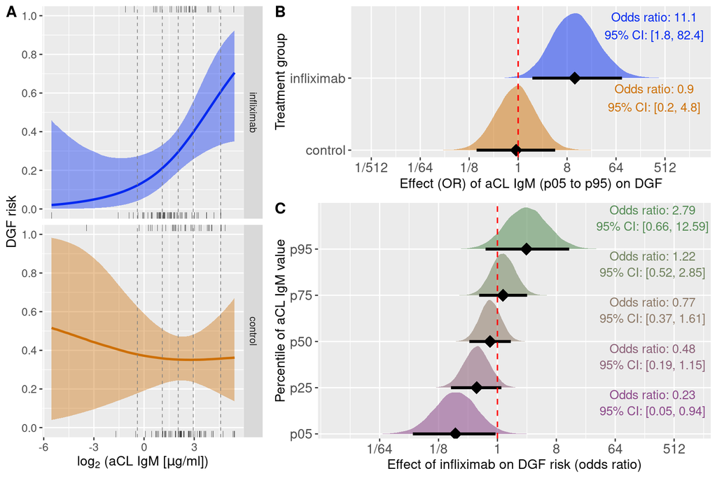

Figure 4: **Anti-cardiolipin IgM modulates infliximab effect on delayed graft function.** (**A**) Predicted DGF risk by anti-cardiolipin IgM for infliximab (upper) and control (lower) groups, with covariates held at their sample means. Shaded regions represent 95% credible intervals; dashed lines indicate the 5th, 25th, 50th, 75th, and 95th percentiles of cardiolipin levels. (**B**) Posterior distribution of the estimated odds ratio comparing DGF odds at the 95th vs. 5th percentile of anti-cardiolipin IgM. (**C**) Posterior distribution of the infliximab effect (odds ratio) on DGF risk across anti-cardiolipin IgM percentiles. Results are from a multivariable Bayesian logistic model with B-splines.

```r
plotac <- 'sup_figure_3'
path <- "gitignore/figures"

fig <- cowplot::plot_grid(fig_b, fig_c,
  rel_heights = c(0.7, 1),
  labels = c("B", "C"),
  ncol = 1
)

assign(
  plotac,
  cowplot::plot_grid(
    fig_a, fig,
    rel_widths = c(0.6, 1),
    labels = c("A", "")
  )
)

get(plotac)

if (file.exists(paste0(path, "/", plotac)) == FALSE) {
  ggsave(
    path = paste0(path),
    filename = plotac,
    device = "pdf",
    width = 9,
    height = 6
  )
}
```

# 8 Infection models

## 8.1 Infection by GPE_dep

### 8.1.1 Priors

#### 8.1.1.1 Main effects model

**Open code**

```r
priors_main <- c(
  create_prior("IGPE_dep_log2P2",
    2 / sd(data_model_priorImpute$GPE_dep_log2, na.rm = TRUE),
    coef = "IGPE_dep_log2P2"
  ),
   create_prior("IHLA_MMM5",
    2 / sd(data_model_priorImpute$HLA_MM, na.rm = TRUE),
    coef = "IHLA_MMM5"
  ),
  create_prior("IKDPIM50",
    2 / sd(data_model_priorImpute$KDPI, na.rm = TRUE),
    coef = "IKDPIM50"
  ),
  create_prior("Irec_ageM50",
    2 / sd(data_model_priorImpute$rec_age, na.rm = TRUE),
    coef = "Irec_ageM50"
),
  create_prior("ICITM15",
    2 / sd(data_model_priorImpute$CIT, na.rm = TRUE),
    coef = "ICITM15"
  ),
  create_prior("male_sex",
    4,
    coef = "male_sex"
  ),
  create_prior("perfusion_event",
    4,
    coef = "perfusion_event"
  ),
  create_prior("male_sex_donor",
    4,
    coef = "male_sex_donor"
  ),
  create_prior("infliximab",
    4,
    coef = "infliximab"
  ),
  set_prior(paste0("normal(", logit(mean(data_model_priorImpute$infection_any)), ", 10)"),
    class = "Intercept"
  )
)
```

#### 8.1.1.2 Non-linear penalized interaction model

**Open code**

```r
priors_interaction_pnl <- c(
  create_prior("Irec_ageM50",
               2 / sd(data_model_priorImpute$rec_age, na.rm = TRUE),
               coef = "Irec_ageM50"),
  create_prior("IHLA_MMM5",
               2 / sd(data_model_priorImpute$HLA_MM, na.rm = TRUE),
               coef = "IHLA_MMM5"),
  create_prior("IKDPIM50",
               2 / sd(data_model_priorImpute$KDPI, na.rm = TRUE),
               coef = "IKDPIM50"),
  create_prior("ICITM15",
               2 / sd(data_model_priorImpute$CIT, na.rm = TRUE),
               coef = "ICITM15"),
  create_prior("male_sex",
               4,
               coef = "male_sex"),
  create_prior("perfusion_event",
               4,
               coef = "perfusion_event"),
  create_prior("male_sex_donor",
               4,
               coef = "male_sex_donor"),

  create_prior("infliximab",
               4,
               coef = "infliximab"),

 set_prior("student_t(3, 0, 0.6)", class = "sds",
           coef = 's(I(GPE_dep_log2 + 2), bs = "ps", k = 5)'),

 set_prior("student_t(3, 0, 0.3)", class = "sds",
           coef = 's(I(GPE_dep_log2 + 2), by = infliximab, bs = "ps", k = 5)'),

  set_prior(paste0("normal(", logit(mean(data_model_priorImpute$infection_any)), ", 10)"),
            class = "Intercept")
)
```

### 8.1.2 Models

#### 8.1.2.1 Main effects models

**Open code**

```r
model_infection_any_GPE_dep_main <- run(
  expr = brm_multiple(
    infection_any ~
      male_sex +
      I(rec_age - 50) +
      male_sex_donor +
      I(KDPI - 50) +
      I(CIT - 15) +
      I(HLA_MM - 5) +
      perfusion_event +
      infliximab +
      I(GPE_dep_log2 + 2),
    family = bernoulli(),
    data = data_imputed,
    prior = priors_main,
    backend = "cmdstanr",
    seed = 2025,
    cores = 4, chains = 4,
    iter = 2000, warmup = 1900,
    control = list(adapt_delta = 0.95)
  ),
  path = "gitignore/run/model_infection_any_GPE_dep_main",
  reuse = TRUE
)

summary(model_infection_any_GPE_dep_main, robust = TRUE)
## Warning: Parts of the model have not converged (some Rhats are > 1.05). Be
## careful when analysing the results! We recommend running more iterations and/or
## setting stronger priors.
##  Family: bernoulli
##   Links: mu = logit
## Formula: infection_any ~ male_sex + I(rec_age - 50) + male_sex_donor + I(KDPI - 50) + I(CIT - 15) + I(HLA_MM - 5) + perfusion_event + infliximab + I(GPE_dep_log2 + 2)
##    Data: data_imputed (Number of observations: 177)
##   Draws: 320 chains, each with iter = 2000; warmup = 1900; thin = 1;
##          total post-warmup draws = 32000
##
## Regression Coefficients:
##                 Estimate Est.Error l-95% CI u-95% CI Rhat Bulk_ESS Tail_ESS
## Intercept          -1.20      0.47    -2.17    -0.30 1.03     8357    25111
## male_sex            0.28      0.36    -0.43     1.01 1.01    35581    26492
## Irec_ageM50        -0.03      0.02    -0.06     0.01 1.01    34812    27578
## male_sex_donor      0.22      0.36    -0.48     0.92 1.01    35747    27955
## IKDPIM50            0.03      0.01     0.02     0.05 1.00    31156    26870
## ICITM15            -0.10      0.03    -0.16    -0.04 1.01    21925    27001
## IHLA_MMM5          -0.27      0.13    -0.53    -0.04 1.05     3743    18243
## perfusion_event    -0.04      0.40    -0.83     0.74 1.07     2925    12861
## infliximab          0.40      0.35    -0.27     1.09 1.01    36151    28346
## IGPE_dep_log2P2    -0.55      0.28    -1.11    -0.02 1.01    35008    27707
##
## Draws were sampled using sample(hmc). For each parameter, Bulk_ESS
## and Tail_ESS are effective sample size measures, and Rhat is the potential
## scale reduction factor on split chains (at convergence, Rhat = 1).
prior_summary(model_infection_any_GPE_dep_main)
##                           prior     class            coef group resp dpar nlpar
##                          (flat)         b
##    normal(0, 0.280307006032291)         b         ICITM15
##     normal(0, 3.05433848490195)         b IGPE_dep_log2P2
##     normal(0, 1.38219051128263)         b       IHLA_MMM5
##   normal(0, 0.0970980394231448)         b        IKDPIM50
##                    normal(0, 4)         b      infliximab
##    normal(0, 0.190589762164436)         b     Irec_ageM50
##                    normal(0, 4)         b        male_sex
##                    normal(0, 4)         b  male_sex_donor
##                    normal(0, 4)         b perfusion_event
##  normal(-0.307484699747961, 10) Intercept
##  lb ub  source
##        default
##           user
##           user
##           user
##           user
##           user
##           user
##           user
##           user
##           user
##           user

tr <- round(exp(fixef(model_infection_any_GPE_dep_main, robust = TRUE)[-1, c(1,3,4)]), 2)
colnames(tr)[1] <- 'OR'
kableExtra::kable(tr)
```

Table 13: Results from multivariable Bayesian logistic regression models examining the main effects of predictors, including `infliximab` treatment and log2-transformed co-factor-dependent phosphatidylethanolamine IgG (`GPE_dep_log2`), on `infection` risk, without interaction terms. The odds ratio (OR) represents the estimated change in the odds of infection per one-unit increase in the predictor. `OR`: odds ratio; `Q2.5` and `Q97.5`: lower and upper bounds of the 95% credible interval, respectively.

|  | OR | Q2.5 | Q97.5 |
| --- | --- | --- | --- |
| male_sex | 1.32 | 0.65 | 2.76 |
| Irec_ageM50 | 0.97 | 0.94 | 1.01 |
| male_sex_donor | 1.24 | 0.62 | 2.51 |
| IKDPIM50 | 1.03 | 1.02 | 1.05 |
| ICITM15 | 0.91 | 0.86 | 0.96 |
| IHLA_MMM5 | 0.76 | 0.59 | 0.97 |
| perfusion_event | 0.96 | 0.44 | 2.09 |
| infliximab | 1.49 | 0.77 | 2.97 |
| IGPE_dep_log2P2 | 0.58 | 0.33 | 0.98 |

#### 8.1.2.2 Non-linear interaction model

**Open code**

```r
model_infection_any_GPE_dep_interaction_NL <- run(
  expr = brm_multiple(
    infection_any ~
    male_sex +
    I(rec_age - 50) +
    male_sex_donor +
    I(KDPI - 50) +
    I(CIT - 15) +
    I(HLA_MM - 5) +
    perfusion_event +
    infliximab +
    s(I(GPE_dep_log2+2), bs = 'ps', k = 5) +
    s(I(GPE_dep_log2+2), by = infliximab, bs = 'ps', k = 5),
    family = bernoulli(),
    data = data_imputed,
    prior = priors_interaction_pnl,
    backend = "cmdstanr",
    seed = 2025,
    cores = 4, chains = 4,
    iter = 2000, warmup = 1900,
    control = list(adapt_delta = 0.95)
  ),
  path = "gitignore/run/model_infection_any_GPE_dep_interaction_NL",
  reuse = TRUE
)

summary(model_infection_any_GPE_dep_interaction_NL, robust = TRUE)
## Warning: Parts of the model have not converged (some Rhats are > 1.05). Be
## careful when analysing the results! We recommend running more iterations and/or
## setting stronger priors.
## Warning: There were 1 divergent transitions after warmup. Increasing
## adapt_delta above 0.95 may help. See
## http://mc-stan.org/misc/warnings.html#divergent-transitions-after-warmup
##  Family: bernoulli
##   Links: mu = logit
## Formula: infection_any ~ male_sex + I(rec_age - 50) + male_sex_donor + I(KDPI - 50) + I(CIT - 15) + I(HLA_MM - 5) + perfusion_event + infliximab + s(I(GPE_dep_log2 + 2), bs = "ps", k = 5) + s(I(GPE_dep_log2 + 2), by = infliximab, bs = "ps", k = 5)
##    Data: data_imputed (Number of observations: 177)
##   Draws: 320 chains, each with iter = 2000; warmup = 1900; thin = 1;
##          total post-warmup draws = 32000
##
## Smoothing Spline Hyperparameters:
##                                   Estimate Est.Error l-95% CI u-95% CI Rhat
## sds(sIGPE_dep_log2P2_1)               0.39      0.36     0.02     1.78 1.01
## sds(sIGPE_dep_log2P2infliximab_1)     0.22      0.21     0.01     1.20 1.00
##                                   Bulk_ESS Tail_ESS
## sds(sIGPE_dep_log2P2_1)              23011    16212
## sds(sIGPE_dep_log2P2infliximab_1)    29739    16611
##
## Regression Coefficients:
##                               Estimate Est.Error l-95% CI u-95% CI Rhat
## Intercept                        -0.96      0.47    -1.89    -0.05 1.02
## male_sex                          0.20      0.37    -0.53     0.93 1.01
## Irec_ageM50                      -0.03      0.02    -0.06     0.01 1.01
## male_sex_donor                    0.15      0.36    -0.57     0.87 1.01
## IKDPIM50                          0.03      0.01     0.01     0.05 1.01
## ICITM15                          -0.10      0.03    -0.16    -0.04 1.01
## IHLA_MMM5                        -0.27      0.12    -0.53    -0.03 1.05
## perfusion_event                   0.02      0.41    -0.77     0.83 1.07
## infliximab                        0.01      3.96    -7.77     7.88 1.02
## sIGPE_dep_log2P2_1               -0.01      1.21    -2.46     2.72 1.01
## sIGPE_dep_log2P2:infliximab_1    -1.54      2.40    -6.31     3.14 1.02
## sIGPE_dep_log2P2:infliximab_2     1.73      1.92    -2.01     5.47 1.01
##                               Bulk_ESS Tail_ESS
## Intercept                        10823    27696
## male_sex                         35504    26209
## Irec_ageM50                      34966    27068
## male_sex_donor                   36837    27583
## IKDPIM50                         33808    25857
## ICITM15                          17002    25866
## IHLA_MMM5                         3867    19114
## perfusion_event                   2911    11736
## infliximab                       12595    17936
## sIGPE_dep_log2P2_1               24856    21147
## sIGPE_dep_log2P2:infliximab_1    14000    20327
## sIGPE_dep_log2P2:infliximab_2    14554    20883
##
## Draws were sampled using sample(hmc). For each parameter, Bulk_ESS
## and Tail_ESS are effective sample size measures, and Rhat is the potential
## scale reduction factor on split chains (at convergence, Rhat = 1).
prior_summary(model_infection_any_GPE_dep_interaction_NL)
##                           prior     class
##                          (flat)         b
##    normal(0, 0.280307006032291)         b
##     normal(0, 1.38219051128263)         b
##   normal(0, 0.0970980394231448)         b
##                    normal(0, 4)         b
##    normal(0, 0.190589762164436)         b
##                    normal(0, 4)         b
##                    normal(0, 4)         b
##                    normal(0, 4)         b
##                          (flat)         b
##                          (flat)         b
##                          (flat)         b
##  normal(-0.307484699747961, 10) Intercept
##            student_t(3, 0, 2.5)       sds
##            student_t(3, 0, 0.6)       sds
##            student_t(3, 0, 0.3)       sds
##                                                       coef group resp dpar
##
##                                                    ICITM15
##                                                  IHLA_MMM5
##                                                   IKDPIM50
##                                                 infliximab
##                                                Irec_ageM50
##                                                   male_sex
##                                             male_sex_donor
##                                            perfusion_event
##                                         sIGPE_dep_log2P2_1
##                              sIGPE_dep_log2P2:infliximab_1
##                              sIGPE_dep_log2P2:infliximab_2
##
##
##                   s(I(GPE_dep_log2 + 2), bs = "ps", k = 5)
##  s(I(GPE_dep_log2 + 2), by = infliximab, bs = "ps", k = 5)
##  nlpar lb ub       source
##                   default
##                      user
##                      user
##                      user
##                      user
##                      user
##                      user
##                      user
##                      user
##              (vectorized)
##              (vectorized)
##              (vectorized)
##                      user
##         0         default
##         0            user
##         0            user

tr2 <- round(exp(fixef(model_infection_any_GPE_dep_interaction_NL,
                       robust = TRUE)[-c(1,9:12), c(1,3,4)]), 3)

antibody_seq <- quantile(data_model_priorImpute$GPE_dep_log2,
                         probs = c(0.05, 0.95))

asl <- length(antibody_seq)
quant_dif <- antibody_seq[2] - antibody_seq[1]

data_prediction <- data.frame(
    male_sex = rep(mmale_sex, 2*length(antibody_seq)),
  `male_sex_donor` = rep(mmale_sex_donor, 2*length(antibody_seq)),
  `perfusion_event` = rep(mperfusion_event, 2*length(antibody_seq)),
  `infliximab` = c(rep(0, length(antibody_seq)), rep(1, length(antibody_seq))),
  `rec_age` = rep(mrec_age, 2*length(antibody_seq)),
  `KDPI` = rep(mKDPI, 2*length(antibody_seq)),
  `CIT` = rep(mCIT, 2*length(antibody_seq)),
  `HLA_MM` = rep(mHLA_MM, 2*length(antibody_seq)),
  `GPE_dep_log2` = c(antibody_seq, antibody_seq)
  )

tr <-  posterior_epred(
    model_infection_any_GPE_dep_interaction_NL,
    newdata = data_prediction)

prediction_ctrl <- tr[, c(1:asl)]
prediction_infliximab <- tr[, c((asl+1):(asl*2))]

## get odds ratio for infliximab effect across antibody values
prediction <- (
  (prediction_infliximab/(1-prediction_infliximab))/
     (prediction_ctrl/(1-prediction_ctrl))
  ) %>% data.frame()
names(prediction) <- c('p05', 'p95')

infliximab_GPE_dep_log2_int <- quantile(
  exp((log(prediction$p95) - log(prediction$p05))/scaling_unit),
         probs = c(0.5, 1/40, 39/40))

tr2 <- rbind(tr2, round(infliximab_GPE_dep_log2_int, 3))
row.names(tr2)[8] <- 'infliximab:GPE_dep_log2'
colnames(tr2)[1] <- '(R)OR'
kableExtra::kable(tr2)
```

Table 14: Results from multivariable Bayesian logistic regression models incorporating a non-linear interaction between co-factor-dependent phosphatidylethanolamine IgG (aPE-dep IgG, `GPE_dep_log2`) and `infliximab` treatment on `infection` risk, while accounting for other covariates. Effects are presented as odds ratios (`OR`), with the last row reporting the ratio of odds ratios (`ROR`). The ROR represents the estimated ratio of infliximab’s treatment effect at the 95th versus the 5th percentile of aPE-dep IgG, quantifying the interaction effect.`Q2.5` and `Q97.5`: lower and upper bounds of the 95% credible interval, respectively.

|  | (R)OR | Q2.5 | Q97.5 |
| --- | --- | --- | --- |
| male_sex | 1.220 | 0.590 | 2.539 |
| Irec_ageM50 | 0.972 | 0.938 | 1.006 |
| male_sex_donor | 1.166 | 0.568 | 2.392 |
| IKDPIM50 | 1.034 | 1.015 | 1.054 |
| ICITM15 | 0.905 | 0.851 | 0.957 |
| IHLA_MMM5 | 0.763 | 0.589 | 0.969 |
| perfusion_event | 1.018 | 0.463 | 2.299 |
| infliximab:GPE_dep_log2 | 0.097 | 0.008 | 0.995 |

### 8.1.3 Visualisation - penalized non-linear effect

Extract posterior draws

**Open code**

```r
antibody_perc <- quantile(data_model_priorImpute$GPE_dep_log2,
                           probs = c(0, 0.02, 0.05, 0.25, 0.5, 0.75, 0.95, 0.98, 1))

antibody_seq <- seq(antibody_perc[1],
                      antibody_perc[length(antibody_perc)],
                      length.out = 101)

## create prediction
data_prediction <- data.frame(
    male_sex = rep(mmale_sex, 2*length(antibody_seq)),
  `male_sex_donor` = rep(mmale_sex_donor, 2*length(antibody_seq)),
  `perfusion_event` = rep(mperfusion_event, 2*length(antibody_seq)),
  `infliximab` = c(rep(0, length(antibody_seq)), rep(1, length(antibody_seq))),
  `rec_age` = rep(mrec_age, 2*length(antibody_seq)),
  `KDPI` = rep(mKDPI, 2*length(antibody_seq)),
  `CIT` = rep(mCIT, 2*length(antibody_seq)),
  `HLA_MM` = rep(mHLA_MM, 2*length(antibody_seq)),
  `GPE_dep_log2` = c(antibody_seq, antibody_seq)
  )

prediction <- data.frame(
  posterior_epred(
    model_infection_any_GPE_dep_interaction_NL,
    newdata = data_prediction) %>% posterior_summary(
      robust = TRUE
      ) %>% data.frame() %>% select(-Est.Error),
  group = factor(if_else(data_prediction$infliximab == 1, 'infliximab', 'control')),
  GPE_dep_log2 = data_prediction$GPE_dep_log2)
```

Figure A

**Open code**

```r
cole <- c('#CD7006', '#0028F0')

fig_a <- prediction %>%
  mutate(group = factor(group, levels = c("infliximab", "control"))) %>%
  ggplot(aes(x = GPE_dep_log2, y = Estimate, col = group, fill = group)) +
  geom_line(aes(y = Estimate), linewidth = 1) +
  scale_y_continuous(limits = c(0, 1),
                     breaks = c(seq(0, 1, by = 0.2))) +

  geom_ribbon(aes(ymin = `Q2.5`, ymax = `Q97.5`),
               alpha = 0.4,  color = NA) +

  labs(x = expression(log[2]~"(aPE IgG dep [OD])"), y = "Infection risk") +
  scale_color_manual(values = cole,
                       name = "group",
                       breaks = c('control', 'infliximab'),
                       labels = c('control', 'infliximab')) +

  scale_fill_manual(values = cole,
                       name = "group",
                       breaks = c('control', 'infliximab'),
                       labels = c('control', 'infliximab')) +

  facet_grid(rows = vars(group)) +

  theme(axis.text=element_text(size=10),
        axis.title=element_text(size=12),
        strip.text.x = element_text(size = 12),
        legend.position = "none") +

  geom_rug(
    data = data_model_priorImpute %>% filter(DGF == 0),
    aes(x = GPE_dep_log2),
    sides = "b",
    color = "black",
    size = 0.12,
    inherit.aes = FALSE
  ) +
  geom_rug(
    data = data_model_priorImpute %>% filter(DGF == 1),
    aes(x = GPE_dep_log2),
     sides = "t",
    color = "black",
    size = 0.12,
    inherit.aes = FALSE
  )  +
  geom_vline(xintercept = antibody_perc[3:7], linetype = 2,
                            color = "grey50", size = 0.3)
```

Figure B

**Open code**

```r
antibody_seq <- antibody_perc[c(3, 7)]
antibody_seq
##        5%       95%
## -3.134163 -1.039488

data_prediction <- data.frame(
   male_sex = rep(mmale_sex, 2*length(antibody_seq)),
  `male_sex_donor` = rep(mmale_sex_donor, 2*length(antibody_seq)),
  `perfusion_event` = rep(mperfusion_event, 2*length(antibody_seq)),
  `infliximab` = c(rep(0, length(antibody_seq)), rep(1, length(antibody_seq))),
  `rec_age` = rep(mrec_age, 2*length(antibody_seq)),
  `KDPI` = rep(mKDPI, 2*length(antibody_seq)),
  `CIT` = rep(mCIT, 2*length(antibody_seq)),
  `HLA_MM` = rep(mHLA_MM, 2*length(antibody_seq)),
  `GPE_dep_log2` = c(antibody_seq, antibody_seq)
  )

tr <-  posterior_epred(
    model_infection_any_GPE_dep_interaction_NL,
    newdata = data_prediction)

tr_ctrl <- (logit(tr[,c(ncol(tr)/2)]) - logit(tr[,c(1)]))
tr_infliximab <- (logit(tr[,c(ncol(tr))]) - logit(tr[,c(ncol(tr)/2)+1]))

post_fix <- data.frame(
  b_GPE_dep_log2 = tr_ctrl,
  b_GPE_dep_log2_infliximab = tr_infliximab
)

tr <- post_fix %>%
  mutate(control = exp(b_GPE_dep_log2),
         infliximab = exp(b_GPE_dep_log2_infliximab)) %>%
  select(control, infliximab) %>%
  data.frame()

CIS <- sapply(
  tr,
  function(p) quantile(p, probs = c(1/40, 39/40, 0.5, 1e-3, 1-1e-3))
  ) %>%
  round(2)

CIS
##       control infliximab
## 2.5%     0.18       0.01
## 97.5%    4.70       0.48
## 50%      0.91       0.09
## 0.1%     0.07       0.00
## 99.9%   12.90       1.23

xpos <- 323

fig_b <- tr %>%
  pivot_longer(values_to = 'value',
               cols = c('control', 'infliximab'),
               names_to = 'group') %>%
  ggplot(aes(x = value, y = group, fill = group)) +

  stat_halfeye(.width = c(0.95), slab_alpha=0.5,
               linewidth = 5,
               shape = 18,
               point_size = 5,
               normalize = "groups",
               p_limits = c(1e-3, 1-1e-3)) +

    labs(x = 'Effect (OR) of aPE IgG dep increase (p05 to p95) on infection',
         y = 'Treatment group') +

  scale_fill_manual(values = cole,
                       name = "Treatment group",
                       breaks = c('control', 'infliximab'),
                       labels = c('control', 'infliximab')) +

  scale_y_discrete(expand = expansion(add = 0.1)) +
  coord_cartesian(xlim = c(1/600, 1800)) +
  scale_x_continuous(transform = 'log2',
                     breaks = c(1/512, 1/64, 1/8, 1, 8, 64, 512),
                     labels = c("1/512", "1/64", "1/8", "1", "8", "64", "512")) +

  geom_vline(xintercept = 1, linetype = 2,
                color = "red", size = 0.6) +

  theme(axis.text = element_text(size = 12),
        axis.title = element_text(size = 12)) +

  theme(legend.position = "none") +

  annotate("text",  x = xpos, y = 2.85 ,
           label = paste0("Odds ratio: ", CIS[3,2]),
           color = cole[2] ) +

  annotate("text",  x = xpos, y = 1.85 ,
           label = paste0("Odds ratio: ", CIS[3,1]),
           color = cole[1] ) +

  annotate("text",  x = xpos, y = 2.6 ,
           label = paste0("95% CI: [", CIS[1,2], ", ", CIS[2,2], "]"),
           color = cole[2] ) +

  annotate("text",  x = xpos, y = 1.6 ,
           label = paste0("95% CI: [", CIS[1,1], ", ", CIS[2,1], "]"),
           color = cole[1] )
```

Figure C

**Open code**

```r
cole <- c("#8B4789", "#8B5F77", "#8B7765", "#6F815C", "#548B54")
xpos <- 240
xseq <- c(1/64, 1/8, 1, 8, 64, 512)

antibody_seq <- antibody_perc[c(3, 4, 5, 6, 7)]
antibody_seq
##        5%       25%       50%       75%       95%
## -3.134163 -2.666576 -2.392137 -2.005782 -1.039488

asl <- length(antibody_seq)

data_prediction <- data.frame(
    male_sex = rep(mmale_sex, 2*length(antibody_seq)),
  `male_sex_donor` = rep(mmale_sex_donor, 2*length(antibody_seq)),
  `perfusion_event` = rep(mperfusion_event, 2*length(antibody_seq)),
  `infliximab` = c(rep(0, length(antibody_seq)), rep(1, length(antibody_seq))),
  `rec_age` = rep(mrec_age, 2*length(antibody_seq)),
  `KDPI` = rep(mKDPI, 2*length(antibody_seq)),
  `CIT` = rep(mCIT, 2*length(antibody_seq)),
  `HLA_MM` = rep(mHLA_MM, 2*length(antibody_seq)),
  `GPE_dep_log2` = c(antibody_seq, antibody_seq)
  )

tr <-  posterior_epred(
    model_infection_any_GPE_dep_interaction_NL,
    newdata = data_prediction)

prediction_ctrl <- tr[, c(1:asl)]

prediction_infliximab <- tr[, c((asl+1):(asl*2))]

prediction <- (
  (prediction_infliximab/(1-prediction_infliximab))/
     (prediction_ctrl/(1-prediction_ctrl))
  ) %>% data.frame()


names(prediction) <- c('p05', 'p25', 'p50', 'p75', 'p95')


CIS <- sapply(
  prediction,
  function(p) quantile(p, probs = c(1/40, 39/40, 0.5, 1e-3, 1-1e-3))
  ) %>% round(3)

CIS
##          p05   p25   p50   p75   p95
## 2.5%   1.147 1.005 0.824 0.492 0.066
## 97.5% 12.692 5.193 3.466 2.425 1.754
## 50%    3.731 2.260 1.676 1.097 0.361
## 0.1%   0.588 0.657 0.561 0.310 0.023
## 99.9% 24.985 8.400 5.455 3.839 4.295

fig_c <- prediction %>%
  pivot_longer(values_to = 'value',
               cols = c('p05', 'p25', 'p50', 'p75', 'p95'),
               names_to = 'GPE_dep_percentile') %>%

  ggplot(aes(y = GPE_dep_percentile, x = value, fill = GPE_dep_percentile)) +

  stat_halfeye(.width = c(0.95), slab_alpha = 0.55,
               linewidth = 5,
               shape = 18,
               point_size = 5,
               normalize = "groups",
               p_limits = c(1e-3, 1-1e-3)) +

  labs(x = "Effect of infliximab on infection risk (odds ratio)",
         y = 'Percentile of aPE IgG dep value') +

  scale_fill_manual(values = cole,
                       name = "Percentile of aCL IgG value",
                       breaks = c('p05', 'p25', 'p50', 'p75', 'p95'),
                       labels = c('p05', 'p25', 'p50', 'p75', 'p95')) +

  coord_cartesian(xlim = c(1/300, 1000)) +
  scale_y_discrete(expand = expansion(add = 0.1)) +
  scale_x_continuous(transform = 'log2',
                     breaks = c(xseq),
                     labels = c("1/64", "1/8", "1", "8", "64", '512')) +


  geom_vline(xintercept = 1, linetype = 2,
                color = "red", size = 0.6) +

  theme(axis.text = element_text(size = 12),
        axis.title = element_text(size = 12)) +

  theme(legend.position = "none") +


    annotate("text",  x = xpos, y = 5.85 ,
           label = paste0("Odds ratio: ", round(CIS[3,5], 2)),
           color = cole[5] ) +

  annotate("text",  x = xpos, y = 4.85,
           label = paste0("Odds ratio: ", round(CIS[3,4], 2)),
           color = cole[4] ) +

  annotate("text",  x = xpos, y = 3.85,
           label = paste0("Odds ratio: ", round(CIS[3,3], 2)),
           color = cole[3] ) +

  annotate("text",  x = xpos, y = 2.85,
           label = paste0("Odds ratio: ", round(CIS[3,2],2 )),
           color = cole[2] ) +

  annotate("text",  x = xpos, y = 1.85,
           label = paste0("Odds ratio: ", round(CIS[3,1], 2)),
           color = cole[1] ) +

  annotate("text",  x = xpos, y = 5.5 ,
           label = paste0("95% CI: [", round(CIS[1,5], 2), ", ",
                          round(CIS[2,5], 2), "]"),
           color = cole[5] ) +

  annotate("text",  x = xpos, y = 4.5 ,
           label = paste0("95% CI: [", round(CIS[1,4], 2), ", ",
                          round(CIS[2,4], 2), "]"),
           color = cole[4] ) +

  annotate("text",  x = xpos, y = 3.5 ,
           label = paste0("95% CI: [", round(CIS[1,3], 2), ", ",
                          round(CIS[2,3], 2), "]"),
           color = cole[3] ) +

  annotate("text",  x = xpos, y = 2.5 ,
           label = paste0("95% CI: [", CIS[1,2], ", ", round(CIS[2,2], 2), "]"),
           color = cole[2] ) +

  annotate("text",  x = xpos, y = 1.5 ,
           label = paste0("95% CI: [", round(CIS[1,1], 2), ", ",
                          round(CIS[2,1], 2), "]"),
           color = cole[1] )
```

#### 8.1.3.1 Figure merged

**Open code**

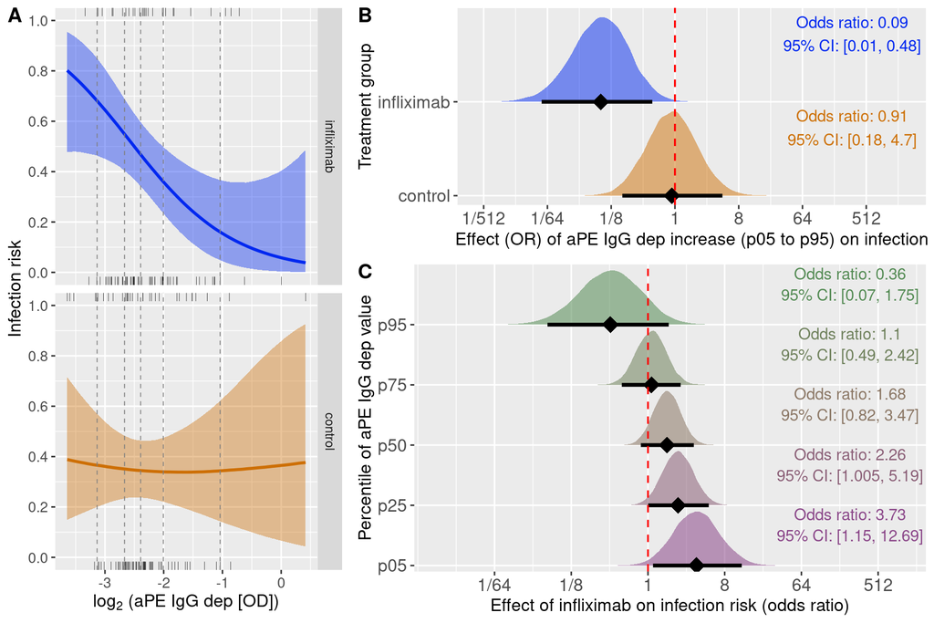

Figure 5: **Co-factor dependent anti-phosphatidylethanolamine IgG (aPE-dep IgG) modulates the effect of infliximab on infection risk** (**A**) Predicted infection risk by aPE-dep IgG for infliximab (upper) and control (lower) groups, with covariates held at their sample means. Shaded regions represent 95% credible intervals; dashed lines indicate the 5th, 25th, 50th, 75th, and 95th percentiles of aPE-dep IgG levels. (**B**) Posterior distribution of the estimated odds ratio comparing infection odds at the 95th vs. 5th percentile of aPE-dep IgG. (**C**) Posterior distribution of the effect of infliximab (odds ratio) on infection risk across aPE-dep IgG percentiles. Results are from a multivariable Bayesian logistic model with B-splines.

```r
plotac <- 'sup_figure_10'
path <- "gitignore/figures"

fig <- cowplot::plot_grid(fig_b, fig_c,
  rel_heights = c(0.7, 1),
  labels = c("B", "C"),
  ncol = 1
)

assign(
  plotac,
  cowplot::plot_grid(
    fig_a, fig,
    rel_widths = c(0.6, 1),
    labels = c("A", "")
  )
)

get(plotac)

if (file.exists(paste0(path, "/", plotac)) == FALSE) {
  ggsave(
    path = paste0(path),
    filename = plotac,
    device = "pdf",
    width = 9,
    height = 6
  )
}
```

## 8.2 Infection by GPE_ind

### 8.2.1 Priors

#### 8.2.1.1 Main effects model

**Open code**

```r
priors_main <- c(
  create_prior("IGPE_ind_log2P3",
    2 / sd(data_model_priorImpute$GPE_ind_log2, na.rm = TRUE),
    coef = "IGPE_ind_log2P3"
  ),
   create_prior("IHLA_MMM5",
    2 / sd(data_model_priorImpute$HLA_MM, na.rm = TRUE),
    coef = "IHLA_MMM5"
  ),
  create_prior("IKDPIM50",
    2 / sd(data_model_priorImpute$KDPI, na.rm = TRUE),
    coef = "IKDPIM50"
  ),
  create_prior("Irec_ageM50",
    2 / sd(data_model_priorImpute$rec_age, na.rm = TRUE),
    coef = "Irec_ageM50"
),
  create_prior("ICITM15",
    2 / sd(data_model_priorImpute$CIT, na.rm = TRUE),
    coef = "ICITM15"
  ),
  create_prior("male_sex",
    4,
    coef = "male_sex"
  ),
  create_prior("perfusion_event",
    4,
    coef = "perfusion_event"
  ),
  create_prior("male_sex_donor",
    4,
    coef = "male_sex_donor"
  ),
  create_prior("infliximab",
    4,
    coef = "infliximab"
  ),
  set_prior(paste0("normal(", logit(mean(data_model_priorImpute$infection_any)), ", 10)"),
    class = "Intercept"
  )
)
```

#### 8.2.1.2 Non-linear penalized interaction model

**Open code**

```r
priors_interaction_pnl <- c(
  create_prior("Irec_ageM50",
               2 / sd(data_model_priorImpute$rec_age, na.rm = TRUE),
               coef = "Irec_ageM50"),
  create_prior("IHLA_MMM5",
               2 / sd(data_model_priorImpute$HLA_MM, na.rm = TRUE),
               coef = "IHLA_MMM5"),
  create_prior("IKDPIM50",
               2 / sd(data_model_priorImpute$KDPI, na.rm = TRUE),
               coef = "IKDPIM50"),
  create_prior("ICITM15",
               2 / sd(data_model_priorImpute$CIT, na.rm = TRUE),
               coef = "ICITM15"),
  create_prior("male_sex",
               4,
               coef = "male_sex"),
  create_prior("perfusion_event",
               4,
               coef = "perfusion_event"),
  create_prior("male_sex_donor",
               4,
               coef = "male_sex_donor"),

  create_prior("infliximab",
               4,
               coef = "infliximab"),

 set_prior("student_t(3, 0, 0.6)", class = "sds",
           coef = 's(I(GPE_ind_log2 + 3), bs = "ps", k = 5)'),

 set_prior("student_t(3, 0, 0.3)", class = "sds",
           coef = 's(I(GPE_ind_log2 + 3), by = infliximab, bs = "ps", k = 5)'),

  set_prior(paste0("normal(", logit(mean(data_model_priorImpute$infection_any)), ", 10)"),
            class = "Intercept")
)
```

### 8.2.2 Models

#### 8.2.2.1 Main effects models

**Open code**

```r
model_infection_any_GPE_ind_main <- run(
  expr = brm_multiple(
    infection_any ~
      male_sex +
      I(rec_age - 50) +
      male_sex_donor +
      I(KDPI - 50) +
      I(CIT - 15) +
      I(HLA_MM - 5) +
      perfusion_event +
      infliximab +
      I(GPE_ind_log2 + 3),
    family = bernoulli(),
    data = data_imputed,
    prior = priors_main,
    backend = "cmdstanr",
    seed = 2025,
    cores = 4, chains = 4,
    iter = 2000, warmup = 1900,
    control = list(adapt_delta = 0.95)
  ),
  path = "gitignore/run/model_infection_any_GPE_ind_main",
  reuse = TRUE
)

summary(model_infection_any_GPE_ind_main, robust = TRUE)
## Warning: Parts of the model have not converged (some Rhats are > 1.05). Be
## careful when analysing the results! We recommend running more iterations and/or
## setting stronger priors.
##  Family: bernoulli
##   Links: mu = logit
## Formula: infection_any ~ male_sex + I(rec_age - 50) + male_sex_donor + I(KDPI - 50) + I(CIT - 15) + I(HLA_MM - 5) + perfusion_event + infliximab + I(GPE_ind_log2 + 3)
##    Data: data_imputed (Number of observations: 177)
##   Draws: 320 chains, each with iter = 2000; warmup = 1900; thin = 1;
##          total post-warmup draws = 32000
##
## Regression Coefficients:
##                 Estimate Est.Error l-95% CI u-95% CI Rhat Bulk_ESS Tail_ESS
## Intercept          -0.98      0.45    -1.90    -0.12 1.02    11019    25593
## male_sex            0.27      0.36    -0.44     1.00 1.01    37004    28448
## Irec_ageM50        -0.02      0.02    -0.06     0.01 1.01    35806    28429
## male_sex_donor      0.21      0.36    -0.48     0.92 1.01    36893    27040
## IKDPIM50            0.03      0.01     0.01     0.05 1.01    33713    27071
## ICITM15            -0.09      0.03    -0.15    -0.04 1.01    20286    25862
## IHLA_MMM5          -0.27      0.12    -0.52    -0.03 1.05     4283    14455
## perfusion_event    -0.00      0.40    -0.79     0.80 1.07     2779    11061
## infliximab          0.33      0.35    -0.34     1.03 1.01    35569    27304
## IGPE_ind_log2P3    -0.42      0.25    -0.94     0.04 1.01    39171    26823
##
## Draws were sampled using sample(hmc). For each parameter, Bulk_ESS
## and Tail_ESS are effective sample size measures, and Rhat is the potential
## scale reduction factor on split chains (at convergence, Rhat = 1).
prior_summary(model_infection_any_GPE_ind_main)
##                           prior     class            coef group resp dpar nlpar
##                          (flat)         b
##    normal(0, 0.280307006032291)         b         ICITM15
##     normal(0, 2.72256264350783)         b IGPE_ind_log2P3
##     normal(0, 1.38219051128263)         b       IHLA_MMM5
##   normal(0, 0.0970980394231448)         b        IKDPIM50
##                    normal(0, 4)         b      infliximab
##    normal(0, 0.190589762164436)         b     Irec_ageM50
##                    normal(0, 4)         b        male_sex
##                    normal(0, 4)         b  male_sex_donor
##                    normal(0, 4)         b perfusion_event
##  normal(-0.307484699747961, 10) Intercept
##  lb ub  source
##        default
##           user
##           user
##           user
##           user
##           user
##           user
##           user
##           user
##           user
##           user

tr <- round(exp(fixef(model_infection_any_GPE_ind_main, robust = TRUE)[-1, c(1,3,4)]), 2)
colnames(tr)[1] <- 'OR'
kableExtra::kable(tr)
```

Table 15: Results from multivariable Bayesian logistic regression models examining the main effects of predictors, including `infliximab` treatment and log2-transformed co-factor-independent phosphatidylethanolamine IgG (`GPE_ind_log2`), on `infection` risk, without interaction terms. The odds ratio (OR) represents the estimated change in the odds of infection per one-unit increase in the predictor. `OR`: odds ratio; `Q2.5` and `Q97.5`: lower and upper bounds of the 95% credible interval, respectively.

|  | OR | Q2.5 | Q97.5 |
| --- | --- | --- | --- |
| male_sex | 1.32 | 0.64 | 2.71 |
| Irec_ageM50 | 0.98 | 0.94 | 1.01 |
| male_sex_donor | 1.23 | 0.62 | 2.51 |
| IKDPIM50 | 1.03 | 1.01 | 1.05 |
| ICITM15 | 0.91 | 0.86 | 0.96 |
| IHLA_MMM5 | 0.77 | 0.59 | 0.97 |
| perfusion_event | 1.00 | 0.45 | 2.23 |
| infliximab | 1.39 | 0.71 | 2.79 |
| IGPE_ind_log2P3 | 0.66 | 0.39 | 1.05 |

#### 8.2.2.2 Non-linear interaction model

**Open code**

```r
model_infection_any_GPE_ind_interaction_NL <- run(
  expr = brm_multiple(
    infection_any ~
    male_sex +
    I(rec_age - 50) +
    male_sex_donor +
    I(KDPI - 50) +
    I(CIT - 15) +
    I(HLA_MM - 5) +
    perfusion_event +
    infliximab +
    s(I(GPE_ind_log2+3), bs = 'ps', k = 5) +
    s(I(GPE_ind_log2+3), by = infliximab, bs = 'ps', k = 5),
    family = bernoulli(),
    data = data_imputed,
    prior = priors_interaction_pnl,
    backend = "cmdstanr",
    seed = 2025,
    cores = 4, chains = 4,
    iter = 2000, warmup = 1900,
    control = list(adapt_delta = 0.95)
  ),
  path = "gitignore/run/model_infection_any_GPE_ind_interaction_NL",
  reuse = TRUE
)

summary(model_infection_any_GPE_ind_interaction_NL, robust = TRUE)
## Warning: Parts of the model have not converged (some Rhats are > 1.05). Be
## careful when analysing the results! We recommend running more iterations and/or
## setting stronger priors.
##  Family: bernoulli
##   Links: mu = logit
## Formula: infection_any ~ male_sex + I(rec_age - 50) + male_sex_donor + I(KDPI - 50) + I(CIT - 15) + I(HLA_MM - 5) + perfusion_event + infliximab + s(I(GPE_ind_log2 + 3), bs = "ps", k = 5) + s(I(GPE_ind_log2 + 3), by = infliximab, bs = "ps", k = 5)
##    Data: data_imputed (Number of observations: 177)
##   Draws: 320 chains, each with iter = 2000; warmup = 1900; thin = 1;
##          total post-warmup draws = 32000
##
## Smoothing Spline Hyperparameters:
##                                   Estimate Est.Error l-95% CI u-95% CI Rhat
## sds(sIGPE_ind_log2P3_1)               0.36      0.33     0.02     1.69 1.01
## sds(sIGPE_ind_log2P3infliximab_1)     0.22      0.21     0.01     1.14 1.00
##                                   Bulk_ESS Tail_ESS
## sds(sIGPE_ind_log2P3_1)              20777    16750
## sds(sIGPE_ind_log2P3infliximab_1)    29345    15825
##
## Regression Coefficients:
##                               Estimate Est.Error l-95% CI u-95% CI Rhat
## Intercept                        -1.01      0.47    -1.96    -0.12 1.03
## male_sex                          0.23      0.37    -0.49     0.97 1.01
## Irec_ageM50                      -0.02      0.02    -0.06     0.01 1.01
## male_sex_donor                    0.20      0.36    -0.51     0.91 1.01
## IKDPIM50                          0.03      0.01     0.01     0.05 1.01
## ICITM15                          -0.10      0.03    -0.16    -0.04 1.01
## IHLA_MMM5                        -0.27      0.13    -0.54    -0.03 1.05
## perfusion_event                   0.06      0.42    -0.77     0.89 1.07
## infliximab                        0.02      3.94    -7.59     7.86 1.02
## sIGPE_ind_log2P3_1               -0.00      0.94    -2.19     1.95 1.01
## sIGPE_ind_log2P3:infliximab_1    -1.90      2.38    -6.69     2.67 1.02
## sIGPE_ind_log2P3:infliximab_2     2.02      2.37    -2.61     6.62 1.02
##                               Bulk_ESS Tail_ESS
## Intercept                         9152    25359
## male_sex                         35120    26888
## Irec_ageM50                      33206    26289
## male_sex_donor                   34551    26083
## IKDPIM50                         32183    26588
## ICITM15                          16827    25092
## IHLA_MMM5                         3866    13123
## perfusion_event                   2824    11080
## infliximab                       12055    17429
## sIGPE_ind_log2P3_1               25340    18221
## sIGPE_ind_log2P3:infliximab_1    13678    20478
## sIGPE_ind_log2P3:infliximab_2    13739    20092
##
## Draws were sampled using sample(hmc). For each parameter, Bulk_ESS
## and Tail_ESS are effective sample size measures, and Rhat is the potential
## scale reduction factor on split chains (at convergence, Rhat = 1).
prior_summary(model_infection_any_GPE_ind_interaction_NL)
##                           prior     class
##                          (flat)         b
##    normal(0, 0.280307006032291)         b
##     normal(0, 1.38219051128263)         b
##   normal(0, 0.0970980394231448)         b
##                    normal(0, 4)         b
##    normal(0, 0.190589762164436)         b
##                    normal(0, 4)         b
##                    normal(0, 4)         b
##                    normal(0, 4)         b
##                          (flat)         b
##                          (flat)         b
##                          (flat)         b
##  normal(-0.307484699747961, 10) Intercept
##            student_t(3, 0, 2.5)       sds
##            student_t(3, 0, 0.6)       sds
##            student_t(3, 0, 0.3)       sds
##                                                       coef group resp dpar
##
##                                                    ICITM15
##                                                  IHLA_MMM5
##                                                   IKDPIM50
##                                                 infliximab
##                                                Irec_ageM50
##                                                   male_sex
##                                             male_sex_donor
##                                            perfusion_event
##                                         sIGPE_ind_log2P3_1
##                              sIGPE_ind_log2P3:infliximab_1
##                              sIGPE_ind_log2P3:infliximab_2
##
##
##                   s(I(GPE_ind_log2 + 3), bs = "ps", k = 5)
##  s(I(GPE_ind_log2 + 3), by = infliximab, bs = "ps", k = 5)
##  nlpar lb ub       source
##                   default
##                      user
##                      user
##                      user
##                      user
##                      user
##                      user
##                      user
##                      user
##              (vectorized)
##              (vectorized)
##              (vectorized)
##                      user
##         0         default
##         0            user
##         0            user

tr2 <- round(exp(fixef(model_infection_any_GPE_ind_interaction_NL,
                       robust = TRUE)[-c(1,9:12), c(1,3,4)]), 2)

antibody_seq <- quantile(data_model_priorImpute$GPE_ind_log2,
                         probs = c(0.05, 0.95))

asl <- length(antibody_seq)
quant_dif <- antibody_seq[2] - antibody_seq[1]

data_prediction <- data.frame(
    male_sex = rep(mmale_sex, 2*length(antibody_seq)),
  `male_sex_donor` = rep(mmale_sex_donor, 2*length(antibody_seq)),
  `perfusion_event` = rep(mperfusion_event, 2*length(antibody_seq)),
  `infliximab` = c(rep(0, length(antibody_seq)), rep(1, length(antibody_seq))),
  `rec_age` = rep(mrec_age, 2*length(antibody_seq)),
  `KDPI` = rep(mKDPI, 2*length(antibody_seq)),
  `CIT` = rep(mCIT, 2*length(antibody_seq)),
  `HLA_MM` = rep(mHLA_MM, 2*length(antibody_seq)),
  `GPE_ind_log2` = c(antibody_seq, antibody_seq)
  )

tr <-  posterior_epred(
    model_infection_any_GPE_ind_interaction_NL,
    newdata = data_prediction)

prediction_ctrl <- tr[, c(1:asl)]
prediction_infliximab <- tr[, c((asl+1):(asl*2))]

## get odds ratio for infliximab effect across antibody values
prediction <- (
  (prediction_infliximab/(1-prediction_infliximab))/
     (prediction_ctrl/(1-prediction_ctrl))
  ) %>% data.frame()
names(prediction) <- c('p05', 'p95')

infliximab_GPE_ind_log2_int <- quantile(
  exp((log(prediction$p95) - log(prediction$p05))/scaling_unit),
         probs = c(0.5, 1/40, 39/40))

tr2 <- rbind(tr2, round(infliximab_GPE_ind_log2_int, 4))
row.names(tr2)[8] <- 'infliximab:GPE_ind_log2'
colnames(tr2)[1] <- '(R)OR'
kableExtra::kable(tr2)
```

Table 16: Results from multivariable Bayesian logistic regression models incorporating a non-linear interaction between co-factor-independent phosphatidylethanolamine IgG (aPE-ind IgG, `GPE_ind_log2`) and `infliximab` treatment on `infection` risk, while accounting for other covariates. Effects are presented as odds ratios (`OR`), with the last row reporting the ratio of odds ratios (`ROR`). The ROR represents the estimated ratio of infliximab’s treatment effect at the 95th versus the 5th percentile of aPE-ind IgG, quantifying the interaction effect.`Q2.5` and `Q97.5`: lower and upper bounds of the 95% credible interval, respectively.

|  | (R)OR | Q2.5 | Q97.5 |
| --- | --- | --- | --- |
| male_sex | 1.2600 | 0.610 | 2.6400 |
| Irec_ageM50 | 0.9800 | 0.940 | 1.0100 |
| male_sex_donor | 1.2200 | 0.600 | 2.4900 |
| IKDPIM50 | 1.0300 | 1.010 | 1.0500 |
| ICITM15 | 0.9100 | 0.850 | 0.9600 |
| IHLA_MMM5 | 0.7600 | 0.590 | 0.9700 |
| perfusion_event | 1.0600 | 0.460 | 2.4300 |
| infliximab:GPE_ind_log2 | 0.0751 | 0.005 | 0.7543 |

### 8.2.3 Visualisation - penalized non-linear effect

Extract posterior draws

**Open code**

```r
antibody_perc <- quantile(data_model_priorImpute$GPE_ind_log2,
                           probs = c(0, 0.02, 0.05, 0.25, 0.5, 0.75, 0.95, 0.98, 1))

antibody_seq <- seq(antibody_perc[1],
                      antibody_perc[length(antibody_perc)],
                      length.out = 101)

## create prediction
data_prediction <- data.frame(
    male_sex = rep(mmale_sex, 2*length(antibody_seq)),
  `male_sex_donor` = rep(mmale_sex_donor, 2*length(antibody_seq)),
  `perfusion_event` = rep(mperfusion_event, 2*length(antibody_seq)),
  `infliximab` = c(rep(0, length(antibody_seq)), rep(1, length(antibody_seq))),
  `rec_age` = rep(mrec_age, 2*length(antibody_seq)),
  `KDPI` = rep(mKDPI, 2*length(antibody_seq)),
  `CIT` = rep(mCIT, 2*length(antibody_seq)),
  `HLA_MM` = rep(mHLA_MM, 2*length(antibody_seq)),
  `GPE_ind_log2` = c(antibody_seq, antibody_seq)
  )

prediction <- data.frame(
  posterior_epred(
    model_infection_any_GPE_ind_interaction_NL,
    newdata = data_prediction) %>% posterior_summary(
      robust = TRUE
      ) %>% data.frame() %>% select(-Est.Error),
  group = factor(if_else(data_prediction$infliximab == 1, 'infliximab', 'control')),
  GPE_ind_log2 = data_prediction$GPE_ind_log2)
```

Figure A

**Open code**

```r
cole <- c('#CD7006', '#0028F0')

fig_a <- prediction %>%
  mutate(group = factor(group, levels = c("infliximab", "control"))) %>%
  ggplot(aes(x = GPE_ind_log2, y = Estimate, col = group, fill = group)) +
  geom_line(aes(y = Estimate), linewidth = 1) +
  scale_y_continuous(limits = c(0, 1),
                     breaks = c(seq(0, 1, by = 0.2))) +

  geom_ribbon(aes(ymin = `Q2.5`, ymax = `Q97.5`),
               alpha = 0.4,  color = NA) +

  labs(x = expression(log[2]~"(aPE IgG ind [OD])"), y = "Infection risk") +
  scale_color_manual(values = cole,
                       name = "group",
                       breaks = c('control', 'infliximab'),
                       labels = c('control', 'infliximab')) +

  scale_fill_manual(values = cole,
                       name = "group",
                       breaks = c('control', 'infliximab'),
                       labels = c('control', 'infliximab')) +

  facet_grid(rows = vars(group)) +

  theme(axis.text=element_text(size=10),
        axis.title=element_text(size=12),
        strip.text.x = element_text(size = 12),
        legend.position = "none") +

  geom_rug(
    data = data_model_priorImpute %>% filter(DGF == 0),
    aes(x = GPE_ind_log2),
    sides = "b",
    color = "black",
    size = 0.12,
    inherit.aes = FALSE
  ) +
  geom_rug(
    data = data_model_priorImpute %>% filter(DGF == 1),
    aes(x = GPE_ind_log2),
     sides = "t",
    color = "black",
    size = 0.12,
    inherit.aes = FALSE
  )  +
  geom_vline(xintercept = antibody_perc[3:7], linetype = 2,
                            color = "grey50", size = 0.3)
```

Figure B

**Open code**

```r
antibody_seq <- antibody_perc[c(3, 7)]
antibody_seq
##        5%       95%
## -3.654722 -1.490602

data_prediction <- data.frame(
   male_sex = rep(mmale_sex, 2*length(antibody_seq)),
  `male_sex_donor` = rep(mmale_sex_donor, 2*length(antibody_seq)),
  `perfusion_event` = rep(mperfusion_event, 2*length(antibody_seq)),
  `infliximab` = c(rep(0, length(antibody_seq)), rep(1, length(antibody_seq))),
  `rec_age` = rep(mrec_age, 2*length(antibody_seq)),
  `KDPI` = rep(mKDPI, 2*length(antibody_seq)),
  `CIT` = rep(mCIT, 2*length(antibody_seq)),
  `HLA_MM` = rep(mHLA_MM, 2*length(antibody_seq)),
  `GPE_ind_log2` = c(antibody_seq, antibody_seq)
  )

tr <-  posterior_epred(
    model_infection_any_GPE_ind_interaction_NL,
    newdata = data_prediction)

tr_ctrl <- (logit(tr[,c(ncol(tr)/2)]) - logit(tr[,c(1)]))
tr_infliximab <- (logit(tr[,c(ncol(tr))]) - logit(tr[,c(ncol(tr)/2)+1]))

post_fix <- data.frame(
  b_GPE_ind_log2 = tr_ctrl,
  b_GPE_ind_log2_infliximab = tr_infliximab
)

tr <- post_fix %>%
  mutate(control = exp(b_GPE_ind_log2),
         infliximab = exp(b_GPE_ind_log2_infliximab)) %>%
  select(control, infliximab) %>%
  data.frame()

CIS <- sapply(
  tr,
  function(p) quantile(p, probs = c(1/40, 39/40, 0.5, 1e-3, 1-1e-3))
  ) %>%
  round(2)

CIS
##       control infliximab
## 2.5%     0.23       0.01
## 97.5%    3.76       0.47
## 50%      0.96       0.07
## 0.1%     0.10       0.00
## 99.9%    8.11       1.19

xpos <- 323

fig_b <- tr %>%
  pivot_longer(values_to = 'value',
               cols = c('control', 'infliximab'),
               names_to = 'group') %>%
  ggplot(aes(x = value, y = group, fill = group)) +

  stat_halfeye(.width = c(0.95), slab_alpha=0.5,
               linewidth = 5,
               shape = 18,
               point_size = 5,
               normalize = "groups",
               p_limits = c(1e-3, 1-1e-3)) +

    labs(x = 'Effect (OR) of aPE IgG ind increase (p05 to p95) on infection',
         y = 'Treatment group') +

  scale_fill_manual(values = cole,
                       name = "Treatment group",
                       breaks = c('control', 'infliximab'),
                       labels = c('control', 'infliximab')) +

  scale_y_discrete(expand = expansion(add = 0.1)) +
  coord_cartesian(xlim = c(1/600, 1800)) +
  scale_x_continuous(transform = 'log2',
                     breaks = c(1/512, 1/64, 1/8, 1, 8, 64, 512),
                     labels = c("1/512", "1/64", "1/8", "1", "8", "64", "512")) +

  geom_vline(xintercept = 1, linetype = 2,
                color = "red", size = 0.6) +

  theme(axis.text = element_text(size = 12),
        axis.title = element_text(size = 12)) +

  theme(legend.position = "none") +

  annotate("text",  x = xpos, y = 2.85 ,
           label = paste0("Odds ratio: ", CIS[3,2]),
           color = cole[2] ) +

  annotate("text",  x = xpos, y = 1.85 ,
           label = paste0("Odds ratio: ", CIS[3,1]),
           color = cole[1] ) +

  annotate("text",  x = xpos, y = 2.6 ,
           label = paste0("95% CI: [", CIS[1,2], ", ", CIS[2,2], "]"),
           color = cole[2] ) +

  annotate("text",  x = xpos, y = 1.6 ,
           label = paste0("95% CI: [", CIS[1,1], ", ", CIS[2,1], "]"),
           color = cole[1] )
```

Figure C

**Open code**

```r
cole <- c("#8B4789", "#8B5F77", "#8B7765", "#6F815C", "#548B54")
xpos <- 240
xseq <- c(1/64, 1/8, 1, 8, 64, 512)

antibody_seq <- antibody_perc[c(3, 4, 5, 6, 7)]
antibody_seq
##        5%       25%       50%       75%       95%
## -3.654722 -3.411195 -3.164884 -2.708396 -1.490602

asl <- length(antibody_seq)

data_prediction <- data.frame(
    male_sex = rep(mmale_sex, 2*length(antibody_seq)),
  `male_sex_donor` = rep(mmale_sex_donor, 2*length(antibody_seq)),
  `perfusion_event` = rep(mperfusion_event, 2*length(antibody_seq)),
  `infliximab` = c(rep(0, length(antibody_seq)), rep(1, length(antibody_seq))),
  `rec_age` = rep(mrec_age, 2*length(antibody_seq)),
  `KDPI` = rep(mKDPI, 2*length(antibody_seq)),
  `CIT` = rep(mCIT, 2*length(antibody_seq)),
  `HLA_MM` = rep(mHLA_MM, 2*length(antibody_seq)),
  `GPE_ind_log2` = c(antibody_seq, antibody_seq)
  )

tr <-  posterior_epred(
    model_infection_any_GPE_ind_interaction_NL,
    newdata = data_prediction)

prediction_ctrl <- tr[, c(1:asl)]

prediction_infliximab <- tr[, c((asl+1):(asl*2))]

prediction <- (
  (prediction_infliximab/(1-prediction_infliximab))/
     (prediction_ctrl/(1-prediction_ctrl))
  ) %>% data.frame()


names(prediction) <- c('p05', 'p25', 'p50', 'p75', 'p95')

CIS <- sapply(
  prediction,
  function(p) quantile(p, probs = c(1/40, 39/40, 0.5, 1e-3, 1-1e-3))
  ) %>%
  round(2)

CIS
##         p05  p25  p50  p75  p95
## 2.5%   1.11 1.01 0.85 0.45 0.03
## 97.5%  9.08 5.56 3.68 2.26 1.33
## 50%    3.12 2.34 1.75 1.02 0.23
## 0.1%   0.63 0.65 0.57 0.27 0.01
## 99.9% 16.77 9.12 5.86 3.60 3.26

fig_c <- prediction %>%
  pivot_longer(values_to = 'value',
               cols = c('p05', 'p25', 'p50', 'p75', 'p95'),
               names_to = 'GPE_ind_percentile') %>%

  ggplot(aes(y = GPE_ind_percentile, x = value, fill = GPE_ind_percentile)) +

  stat_halfeye(.width = c(0.95), slab_alpha = 0.55,
               linewidth = 5,
               shape = 18,
               point_size = 5,
               normalize = "groups",
               p_limits = c(1e-3, 1-1e-3)) +

  labs(x = "Effect of infliximab on infection risk (odds ratio)",
         y = 'Percentile of aPE IgG ind value') +

  scale_fill_manual(values = cole,
                       name = "Percentile of aCL IgG value",
                       breaks = c('p05', 'p25', 'p50', 'p75', 'p95'),
                       labels = c('p05', 'p25', 'p50', 'p75', 'p95')) +

  coord_cartesian(xlim = c(1/300, 1000)) +
  scale_y_discrete(expand = expansion(add = 0.1)) +
  scale_x_continuous(transform = 'log2',
                     breaks = c(xseq),
                     labels = c("1/64", "1/8", "1", "8", "64", '512')) +


  geom_vline(xintercept = 1, linetype = 2,
                color = "red", size = 0.6) +

  theme(axis.text = element_text(size = 12),
        axis.title = element_text(size = 12)) +

  theme(legend.position = "none") +


  annotate("text",  x = xpos, y = 5.85 ,
           label = paste0("Odds ratio: ", CIS[3,5]),
           color = cole[5] ) +

  annotate("text",  x = xpos, y = 4.85,
           label = paste0("Odds ratio: ", CIS[3,4]),
           color = cole[4] ) +

  annotate("text",  x = xpos, y = 3.85,
           label = paste0("Odds ratio: ", CIS[3,3]),
           color = cole[3] ) +

  annotate("text",  x = xpos, y = 2.85,
           label = paste0("Odds ratio: ", CIS[3,2]),
           color = cole[2] ) +

  annotate("text",  x = xpos, y = 1.85,
           label = paste0("Odds ratio: ", CIS[3,1]),
           color = cole[1] ) +

  annotate("text",  x = xpos, y = 5.5 ,
           label = paste0("95% CI: [", CIS[1,5], ", ", CIS[2,5], "]"),
           color = cole[5] ) +

  annotate("text",  x = xpos, y = 4.5 ,
           label = paste0("95% CI: [", CIS[1,4], ", ", CIS[2,4], "]"),
           color = cole[4] ) +

  annotate("text",  x = xpos, y = 3.5 ,
           label = paste0("95% CI: [", CIS[1,3], ", ", CIS[2,3], "]"),
           color = cole[3] ) +

  annotate("text",  x = xpos, y = 2.5 ,
           label = paste0("95% CI: [", CIS[1,2], ", ", CIS[2,2], "]"),
           color = cole[2] ) +

  annotate("text",  x = xpos, y = 1.5 ,
           label = paste0("95% CI: [", CIS[1,1], ", ", CIS[2,1], "]"),
           color = cole[1] )
```